# Machine Learning Model For Fetal Health Prediction

2022/12/09

## Introduction

With the development of obstetric technology, especially the fetal safety monitoring technology, more and more attention is paid to the attention and treatment of the fetus. This is different from the past. In the past, due to technical limitations, obstetrics mainly focused on the mother, and must ensure the safety of the mother. The fetus must be considered as the second priority. Now, of course, the safety of the mother is equally important, but at the same time when considering the safety of the mother (note that it is also not the second priority), it is also considered how to do something beneficial to the fetus.  
Cardiotocograms (CTGs) are a simple and cost accessible option to assess fetal health, allowing healthcare professionals to take action in order to prevent child and maternal mortality. The equipment itself works by sending ultrasound pulses and reading its response, thus shedding light on fetal heart rate (FHR), fetal movements, uterine contractions and more.  
We use exploratory data analysis and machine learning algorithms to study which CTGs indicators during pregnancy are related to the health of the fetus, and predict whether the fetus is healthy according to these indicators, so that people can take medical measures in advance to improve the health rate of the fetus.

## Loading Data and Packages

The data set contains 2126 records of features extracted from cardiotocogram exams. The dependent variable is fetal health, including normal(value=1), suspect(value=2) and pathological(value=3).The independent variable has 21 variables, recorded features extracted from cardiotocogram exams.  
The data for this project comes from the kaggle competition platform see https://www.kaggle.com/datasets/andrewmvd/fetal-health-classification?datasetId=916586&language=R&select=fetal_health.csv  
The variables for the data set are as following:  
baseline_value: Baseline Fetal Heart Rate (FHR)  
accelerations: Number of accelerations per second  
fetal_movement: Number of fetal movements per second  
uterine_contractions: uterine_contractions  
light_decelerations: Number of LDs per second  
severe_decelerations: Number of SDs per second  
prolongued_decelerations: Number of PDs per second  
abnormal_short_term_variability: Percentage of time with abnormal short term variability  
mean_value_of_short_term_variability: Mean value of short term variability  
percentage_of_time_with_abnormal_long_term_variability: Percentage of time with abnormal long term variability  
mean_value_of_long_term_variability: Mean value of long term variability  
histogram_width: Width of the histogram made using all values from a record  
histogram_min: Histogram minimum value  
histogram_max: Histogram maximum value  
histogram_number_of_peaks: Number of peaks in the exam histogram  
histogram_number_of_zeroes: Number of zeroes in the exam histogram  
histogram_mode: Hist mode  
histogram_mean: Hist mean  
histogram_median: Hist Median  
histogram_variance: Hist variance  
histogram_tendency: Histogram trend  
fetal_health: 1-Normal, 2 - Suspect, 3 - Pathological

```r
library(tidyverse)
library(tidymodels)
library(corrplot)
library(caret)
library(janitor)
library(skimr)
library(klaR)
library(MASS)
library(installr)
library(kernlab)
library(patchwork)
library(lubridate)
library(ranger)
library(rlang)
library(ggplot2)
library(corrr)
library(kknn)
tidymodels_prefer()
setwd('C:/Users/DELL/Desktop/131/final project/1130Rmodel')
fetal <- read_csv("fetal_health.csv")
#View(fetal)
```

## Data Cleaning

### Clean names

Standardize the format of column names using clean_names (), mainly replace the space of column name with ’_’.

```r
fetal_ori <- fetal
fetal <- fetal %>% clean_names()
head(fetal)
```

```
## # A tibble: 6 x 22
##   baseline_value accelerations fetal_movement uterine_contract~ light_decelerat~
##            <dbl>         <dbl>          <dbl>             <dbl>            <dbl>
## 1            120         0                  0             0                0
## 2            132         0.006              0             0.006            0.003
## 3            133         0.003              0             0.008            0.003
## 4            134         0.003              0             0.008            0.003
## 5            132         0.007              0             0.008            0
## 6            134         0.001              0             0.01             0.009
## # ... with 17 more variables: severe_decelerations <dbl>,
## #   prolongued_decelerations <dbl>, abnormal_short_term_variability <dbl>,
## #   mean_value_of_short_term_variability <dbl>,
## #   percentage_of_time_with_abnormal_long_term_variability <dbl>,
## #   mean_value_of_long_term_variability <dbl>, histogram_width <dbl>,
## #   histogram_min <dbl>, histogram_max <dbl>, histogram_number_of_peaks <dbl>,
## #   histogram_number_of_zeroes <dbl>, histogram_mode <dbl>, ...
```

### checking missing values

We confirmed that none of the variables have missing values.

```r
apply(is.na(fetal), 2, sum)
```

```
##                                         baseline_value
##                                                      0
##                                          accelerations
##                                                      0
##                                         fetal_movement
##                                                      0
##                                   uterine_contractions
##                                                      0
##                                    light_decelerations
##                                                      0
##                                   severe_decelerations
##                                                      0
##                               prolongued_decelerations
##                                                      0
##                        abnormal_short_term_variability
##                                                      0
##                   mean_value_of_short_term_variability
##                                                      0
## percentage_of_time_with_abnormal_long_term_variability
##                                                      0
##                    mean_value_of_long_term_variability
##                                                      0
##                                        histogram_width
##                                                      0
##                                          histogram_min
##                                                      0
##                                          histogram_max
##                                                      0
##                              histogram_number_of_peaks
##                                                      0
##                             histogram_number_of_zeroes
##                                                      0
##                                         histogram_mode
##                                                      0
##                                         histogram_mean
##                                                      0
##                                       histogram_median
##                                                      0
##                                     histogram_variance
##                                                      0
##                                     histogram_tendency
##                                                      0
##                                           fetal_health
##                                                      0
```

### Convert to factor

The target variable fetal_health is numerical, so we need to convert it into a factor variable.

```r
str(fetal)
fetal$fetal_health = as.factor(fetal$fetal_health)
```

## Exploratory Data Analysis

### Distribution of fetal health

We first drew the distribution plot of our prediction variable (fetal health), and the data showed that most of the fetuses were normal (fatal_health=1), and the number of fetuses with suspect diseases (fatal_health=2) was slightly higher than the number of pathological fetuses(fatal_health=3).

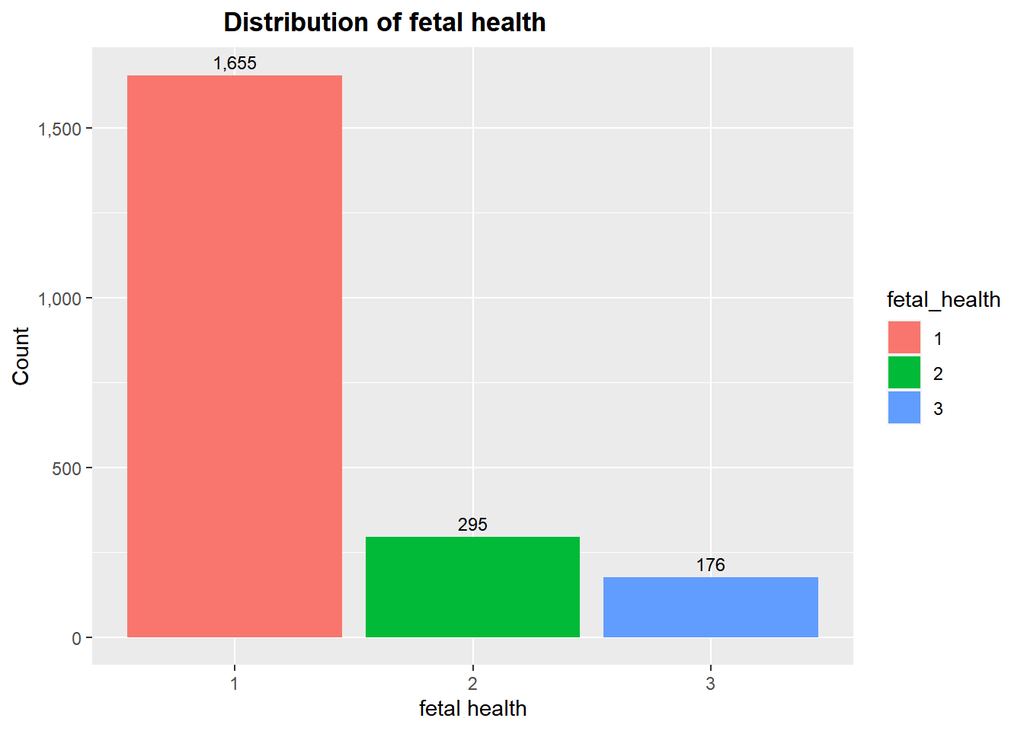

```r
theme <- theme(plot.title = element_text(hjust = 0.3, face = "bold"))

fetal%>%
  ggplot(aes(x = fetal_health,
             y = stat(count), fill = fetal_health,
             label = scales::comma(stat(count)))) +
  geom_bar(position = "dodge") +
  geom_text(stat = 'count',
            position = position_dodge(.9),
            vjust = -0.5,
            size = 3) +
  scale_y_continuous(labels = scales::comma)+
  labs(x = 'fetal health', y = 'Count') +
  ggtitle("Distribution of fetal health") +
  theme
```

### correlation between

We plotted the correlation coefficient matrix between each variable and extracted the correlation coefficient values between each independent variable and the target variable (fetal_health). The results show that number of PDs per second (prolongued_decelerations) has the greatest correlation with fetal_health, the correlation coefficient was 0.48, followed by percentage of time with abnormal short term variability (abnormal_short_term_variability), the correlation coefficient with fetal_health is 0.47.At the same time, each independent variable has different degrees of correlation.

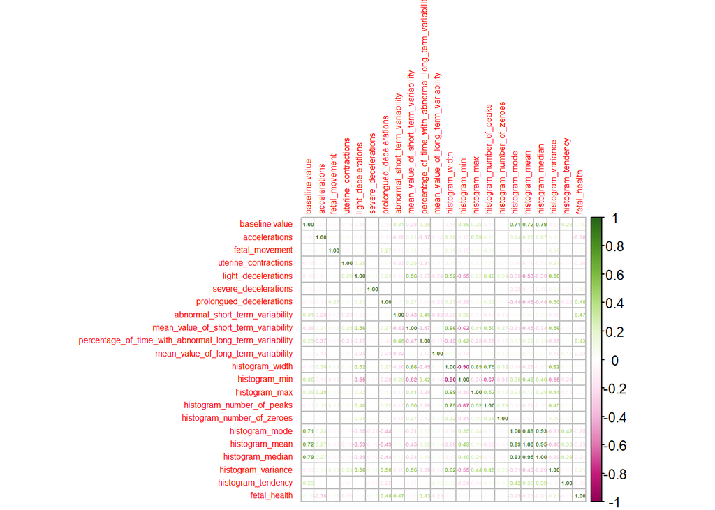

```r
fetal_cor <- cor(fetal_ori)  # calculating the correlation between each variable
cor_plt <- corrplot(fetal_cor, tl.cex = 0.5,number.cex = 0.3,method = "number",col = COL2("PiYG"))
```

```r
fetal_cor[,"fetal_health"]
```

```
##                                         baseline value
##                                             0.14815113
##                                          accelerations
##                                            -0.36406579
##                                         fetal_movement
##                                             0.08801001
##                                   uterine_contractions
##                                            -0.20489372
##                                    light_decelerations
##                                             0.05887049
##                                   severe_decelerations
##                                             0.13193413
##                               prolongued_decelerations
##                                             0.48485919
##                        abnormal_short_term_variability
##                                             0.47119075
##                   mean_value_of_short_term_variability
##                                            -0.10338212
## percentage_of_time_with_abnormal_long_term_variability
##                                             0.42614642
##                    mean_value_of_long_term_variability
##                                            -0.22679707
##                                        histogram_width
##                                            -0.06878876
##                                          histogram_min
##                                             0.06317491
##                                          histogram_max
##                                            -0.04526537
##                              histogram_number_of_peaks
##                                            -0.02366595
##                             histogram_number_of_zeroes
##                                            -0.01668181
##                                         histogram_mode
##                                            -0.25041181
##                                         histogram_mean
##                                            -0.22698518
##                                       histogram_median
##                                            -0.20503300
##                                     histogram_variance
##                                             0.20662962
##                                     histogram_tendency
##                                            -0.13197642
##                                           fetal_health
##                                             1.00000000
```

### fetal health vs baseline_value

To explore the relationship between fetal health and Baseline Fetal Heart Rate, we divided the Baseline Fetal Heart Rate (baseline_value) into 10 intervals, and graphed the proportion of fetal health in each interval. The results show that the proportion of fetal state of the Baseline Fetal Heart Rate in different intervals is different, especially when the Baseline Fetal Heart Rate is greater than 136, the proportion of the suspected fetal pathologies (fetal health=2) increases greatly.

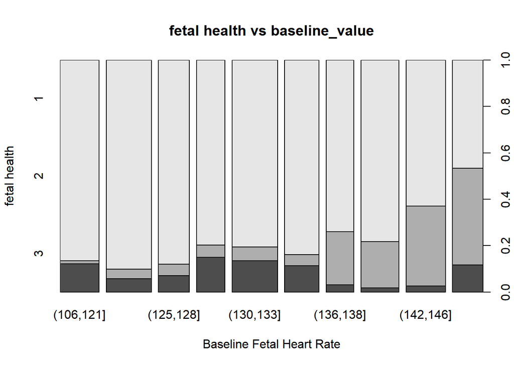

```r
probs = seq(0,1,0.1)
qq = unique(quantile(fetal$baseline_value,probs))
plot(cut(fetal$baseline_value, qq, include_lowest=TRUE), fetal$fetal_health
         , main='fetal health vs baseline_value',fill=fetal$fetal_health
         ,xlab='Baseline Fetal Heart Rate',ylab='fetal health')
```

### Distribution of the fetal health by histogram_tendency

The distribution of the fetal health in different histogram_tendency is different, and the proportion of the pathological fetuses (fetal_health = 3) gradually decreases as the histogram_tendency value increases.

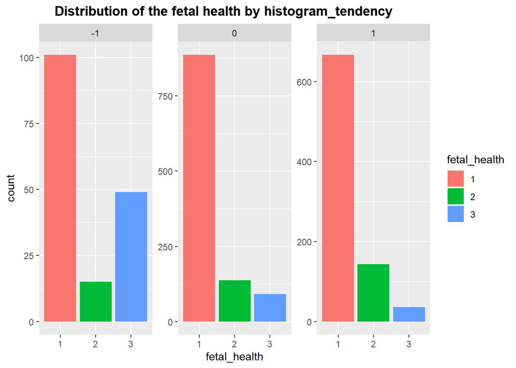

```r
fetal %>%
  ggplot(aes(x = fetal_health,
           y = stat(count), fill = fetal_health)) +
  geom_bar( ) +
  facet_wrap(~histogram_tendency, scales = "free_y") +
  labs(
    title = "Distribution of the fetal health by histogram_tendency"
  )+
  theme
```

### Boxplot of Number of PDs per second by fetal health

It is obvious that the number of PDs per second of pathological fetus is higher than that of other fetus, and the number of PDs per second of normal fetus and suspicious pathological fetus is mostly 0.

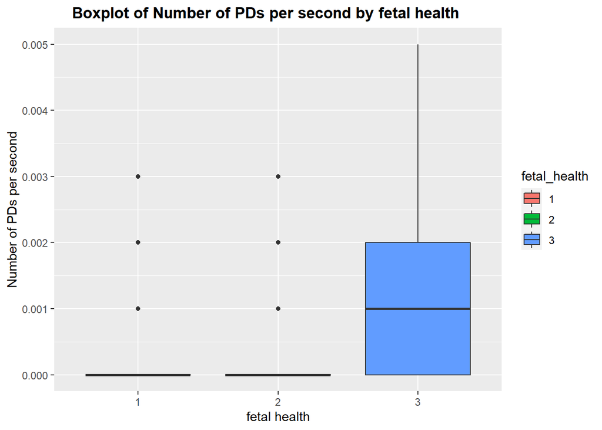

```r
fetal %>%
  ggplot(aes(x = fetal_health, y = prolongued_decelerations,fill = fetal_health)) +
  geom_boxplot() +
  labs(x = 'fetal health', y = 'Number of PDs per second') +
  ggtitle("Boxplot of Number of PDs per second by fetal health") +
  theme
```

## Setting Up Models

### Data Split

```r
set.seed(321)
dim(fetal) #2126   22
```

```
## [1] 2126   22
```

```r
split_data <-fetal %>%
  initial_split(fetal,prop = 0.7, strata = "fetal_health")
fetal_train <- training(split_data)
fetal_test <- testing(split_data)
dim(fetal_train) # 1488   22
```

```
## [1] 1488   22
```

```r
dim(fetal_test)  #  638  22
```

```
## [1] 638  22
```

### Building the Recipe

It’s finally time to start setting up our models! We create our recipe, since all predictor variables are numerical types, we normalize all independent variables to have a standard deviation of one and a mean of zero.and establish 5 fold cross validation and repeated three times to compare each model.

```r
fetal_folds <- vfold_cv(fetal_train, v = 5,repeats = 3)
recipe<-fetal_train %>%
  recipe(fetal_health~.) %>%
  step_normalize(all_predictors())
recipe
```

```
## Recipe
##
## Inputs:
##
##       role #variables
##    outcome          1
##  predictor         21
##
## Operations:
##
## Centering and scaling for all_predictors()
```

## Model building

I decided to run cross fold validation on the following four models.  
1.Logistic regression model 2.Decision tree model  
3.Boost model  
4.SVM model

### Logistic Regression Model

I tuned penalty, set mode to “classification” (because my outcome is a factor variable), and used the LiblineaR engine.

```r
log_model <- logistic_reg() %>%
  set_engine("LiblineaR")%>%
  set_mode('classification')%>%
  set_args(penalty = tune())

log_workflow <- workflow() %>%
  add_model(log_model) %>%
  add_recipe(recipe)

log_grid <- tibble(penalty = 10^seq(-5, 0, length.out = 20))
```

Then, I executed my model by tuning and save model result. This process took 3 minutes, it is quickly.

```r
log_tune_res <- log_workflow %>%
  tune_grid(resamples = fetal_folds,
            grid = log_grid,
            control = control_grid(save_pred = TRUE),
            metrics = metric_set(roc_auc))


save(log_tune_res, log_workflow, file = "C:/Users/DELL/Desktop/131/final project/1130Rmodel/log_tune_res2.rda")
```

Loading model tuning results.Through autoplot() function and show_ best() based on roc_auc metric gets the optimal value of the parameter.As penalty increases, the mean roc_auc is increased rapidly and drops rapidly after reaching the peak, and when penalty=0.16237767, mean roc_auc reaches a maximum value of 94.55%.

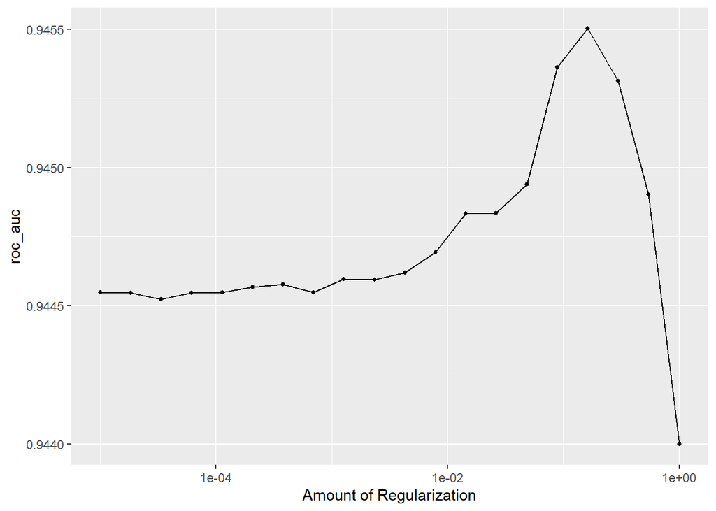

```r
load("C:/Users/DELL/Desktop/131/final project/1130Rmodel/log_tune_res2.rda")
autoplot(log_tune_res, metric = "roc_auc")
```

```r
show_best(log_tune_res, metric = "roc_auc") %>% dplyr::select(-.estimator, -.config) #0.16237767 0.9455037
```

```
## # A tibble: 5 x 5
##   penalty .metric  mean     n std_err
##     <dbl> <chr>   <dbl> <int>   <dbl>
## 1  0.162  roc_auc 0.946    15 0.00415
## 2  0.0886 roc_auc 0.945    15 0.00418
## 3  0.298  roc_auc 0.945    15 0.00416
## 4  0.0483 roc_auc 0.945    15 0.00424
## 5  0.546  roc_auc 0.945    15 0.00402
```

### Decision tree

I tuned cost_complexity, set mode to “classification”, and used the rpart engine to build a decision tree model.

```r
tree_model<- decision_tree() %>%
  set_engine("rpart") %>%
  set_mode("classification") %>%
  set_args(cost_complexity = tune())

tree_workflow <- workflow() %>%
  add_model(tree_model) %>%
  add_recipe(recipe)

tree_grid <- tibble(cost_complexity = 10^seq(-6, -1, length.out = 20))
```

Then, I executed my model by tuning and save model result. This process took 3 minutes, it is quickly.

```r
tree_tune_res <- tune_grid(
  tree_workflow,
  resamples = fetal_folds,
  grid = tree_grid,
  metrics = metric_set(roc_auc)
  )
save(tree_tune_res, tree_workflow, file = "C:/Users/DELL/Desktop/131/final project/1130Rmodel/tree_tune_res2.rda")
```

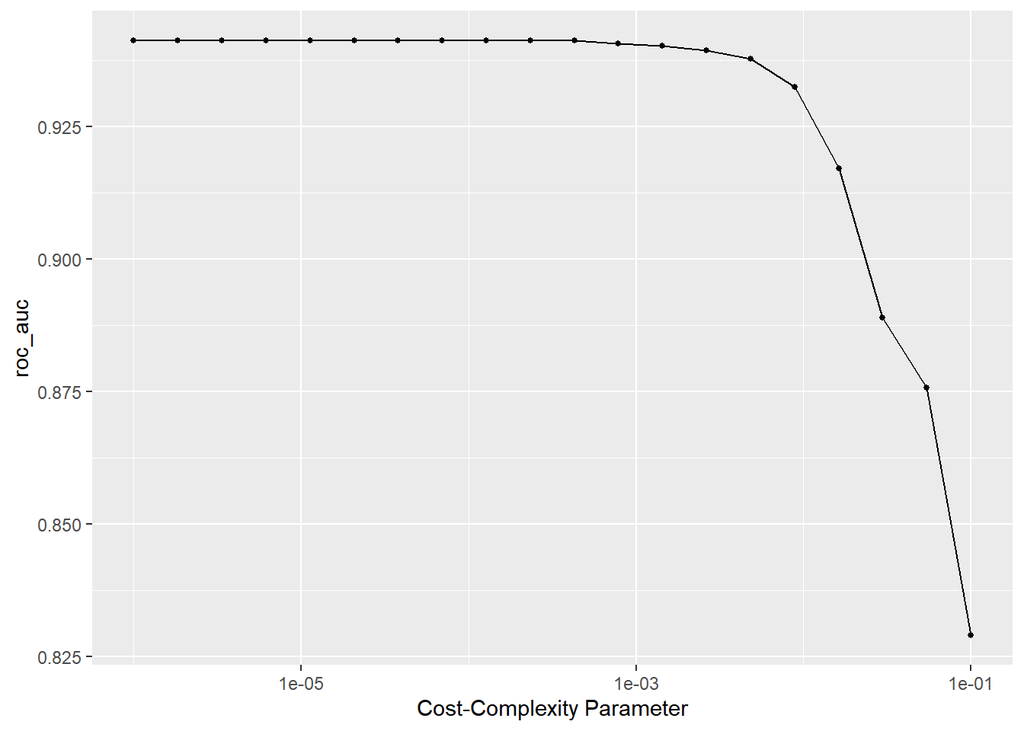

```r
set.seed(321)
load("C:/Users/DELL/Desktop/131/final project/1130Rmodel/tree_tune_res2.rda")
autoplot(tree_tune_res, metric = "roc_auc")
```

```r
show_best(tree_tune_res, metric = "roc_auc") %>% select(-.estimator, -.config) #cost=0.000001 mean=0.9412431
```

```
## # A tibble: 5 x 5
##   cost_complexity .metric  mean     n std_err
##             <dbl> <chr>   <dbl> <int>   <dbl>
## 1      0.000001   roc_auc 0.941    15 0.00378
## 2      0.00000183 roc_auc 0.941    15 0.00378
## 3      0.00000336 roc_auc 0.941    15 0.00378
## 4      0.00000616 roc_auc 0.941    15 0.00378
## 5      0.0000113  roc_auc 0.941    15 0.00378
```

### Boost model

I tuned learn_rate, set mode to “classification”, and used the xgboost engine.

```r
boost_model <- boost_tree() %>%
  set_engine("xgboost") %>%
  set_mode("classification") %>%
  set_args(learn_rate = tune())

boost_workflow <- workflow() %>%
  add_model(boost_model) %>%
  add_recipe(recipe)

boost_grid <- tibble(learn_rate= 10^seq(-3, 0, length.out = 20))
```

Then, I executed my model by tuning and save model result. This process took 3 minutes, it is quickly.

```r
boost_tune_res <- tune_grid(
  boost_workflow,
  resamples = fetal_folds,
  grid = boost_grid,
  metrics = metric_set(roc_auc)
  )
save(boost_tune_res, boost_workflow, file = "C:/Users/DELL/Desktop/131/final project/1130Rmodel/boost_tune_res2.rda")
```

Loading model tuning results.Through autoplot() function and show_ best() based on roc_auc metric gets the optimal value of the parameter.As learning rate increases, the mean roc_auc increases rapidly at first and then decreases slowly after reaching the peak, and when learning rate=0.3359818, mean roc_auc reaches a maximum value of 97.95%.

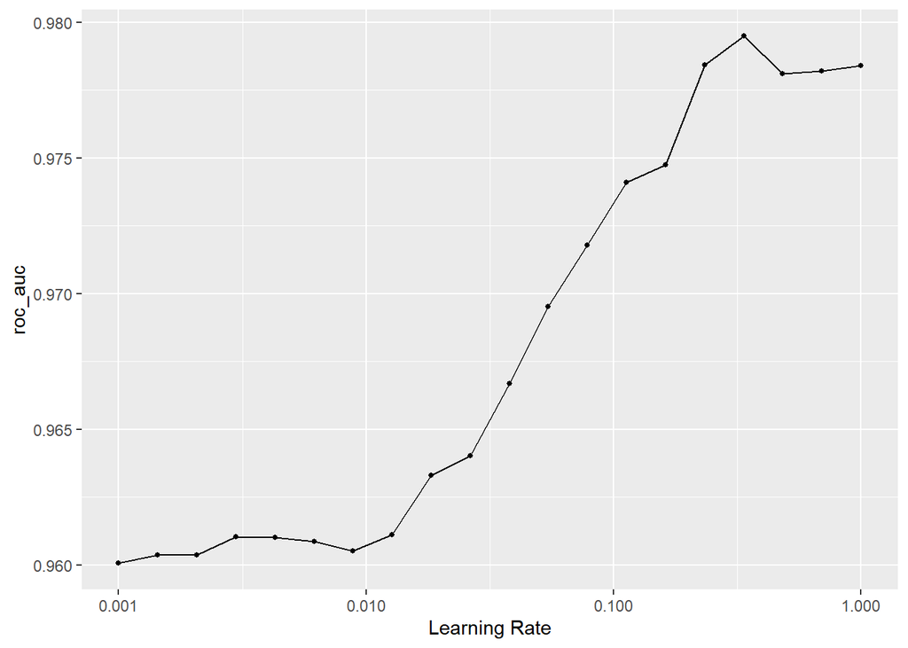

```r
set.seed(321)
load("C:/Users/DELL/Desktop/131/final project/1130Rmodel/boost_tune_res2.rda")
autoplot(boost_tune_res, metric = "roc_auc")  ##
```

```r
show_best(boost_tune_res, metric = "roc_auc") %>% select(-.estimator, -.config)  #learn_rate=0.3359818 #0.9794887
```

```
## # A tibble: 5 x 5
##   learn_rate .metric  mean     n std_err
##        <dbl> <chr>   <dbl> <int>   <dbl>
## 1      0.336 roc_auc 0.979    15 0.00209
## 2      0.234 roc_auc 0.978    15 0.00212
## 3      1     roc_auc 0.978    15 0.00210
## 4      0.695 roc_auc 0.978    15 0.00217
## 5      0.483 roc_auc 0.978    15 0.00221
```

### SVM model

I tuned cost, set mode to “classification” and used the kernlab engine to bulid SVM model.

```r
svm_model <- svm_rbf() %>%
  set_engine("kernlab")%>%
  set_mode('classification')%>%
  set_args(cost  = tune())

svm_workflow <- workflow() %>%
  add_model(svm_model) %>%
  add_recipe(recipe)

svm_grid <- tibble(cost = 10^seq(-3, 3, length.out = 20))
```

Then, I executed my model by tuning and save result. This process took 7 minutes, it is quickly.

```r
set.seed(321)
svm_tune_res <- svm_workflow %>%
  tune_grid(resamples = fetal_folds,
            grid = svm_grid
           )
save(svm_tune_res, svm_workflow, file = "C:/Users/DELL/Desktop/131/final project/1130Rmodel/svm_tune_res2.rda")
```

Loading model tuning results. Through autoplot() function and show_ best() based on roc_auc metric gets the optimal value of the parameter. Overall, as cost increases, the mean roc_auc increases rapidly and then decreases slowly after reaching the peak, and when cost=26.366509, mean roc_auc reaches a maximum value of 96.41%.

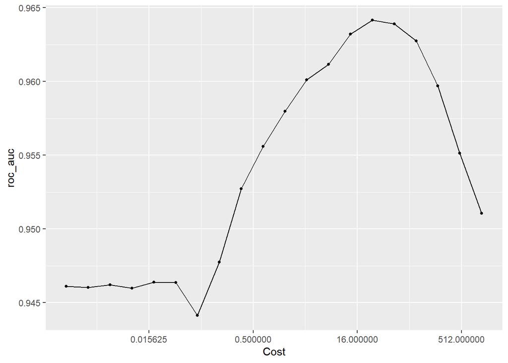

```r
set.seed(321)
load("C:/Users/DELL/Desktop/131/final project/1130Rmodel/svm_tune_res2.rda")
autoplot(svm_tune_res, metric = "roc_auc")
```

```r
show_best(svm_tune_res, metric = "roc_auc") %>% select(-.estimator, -.config) #26.366509  0.9641530
```

```
## # A tibble: 5 x 5
##     cost .metric  mean     n std_err
##    <dbl> <chr>   <dbl> <int>   <dbl>
## 1  26.4  roc_auc 0.964    15 0.00259
## 2  54.6  roc_auc 0.964    15 0.00257
## 3  12.7  roc_auc 0.963    15 0.00268
## 4 113.   roc_auc 0.963    15 0.00288
## 5   6.16 roc_auc 0.961    15 0.00259
```

## Final Model Building

By comparing the mean roc_auc maximum of the four models, boost model performs best, its mean roc_auc value is the highest, close to 97.95%.Therefore, we choose the tuned boost model as our final model.

```r
mean_roc_auc <- c(0.9455, 0.9412, 0.9795,0.9641)
models <- c("Logistic regression model", "Decision tree model", "Boosted tree model","SVM model")
results <- tibble(mean_roc_auc = mean_roc_auc, models = models)

results %>%
  arrange(-mean_roc_auc)
```

```
## # A tibble: 4 x 2
##   mean_roc_auc models
##          <dbl> <chr>
## 1        0.980 Boosted tree model
## 2        0.964 SVM model
## 3        0.946 Logistic regression model
## 4        0.941 Decision tree model
```

We’ll create a workflow that has tuned and finalize the workflow by taking the parameters from the boost model using the select_best() function. Then fit optimal boost model to training set.

```r
set.seed(321)
boost_workflow_tuned <- boost_workflow %>%
  finalize_workflow(select_best(boost_tune_res, metric = "roc_auc"))
boost_final <- fit(boost_workflow_tuned, fetal_train)
```

## Analysis of The Test Set

Let’s fit the final boost model with the test data set, calculate the accuracy and draw the confusion matrix and roc curve.  
The results show that the model performs well on the test set, with an accuracy rate of 95.45%. Through the confusion matrix, we observed that the prediction accuracy of normal fetus(y=1) and pathological fetus(y=3) is very high, but the prediction effect of suspicious pathological fetus(y=2) is not good.

```r
set.seed(321)
#calculate accuracy
boost_acc <- augment(boost_final, new_data = fetal_test) %>%
  accuracy(truth = fetal_health, estimate = .pred_class)
boost_acc
```

```
## # A tibble: 1 x 3
##   .metric  .estimator .estimate
##   <chr>    <chr>          <dbl>
## 1 accuracy multiclass     0.955
```

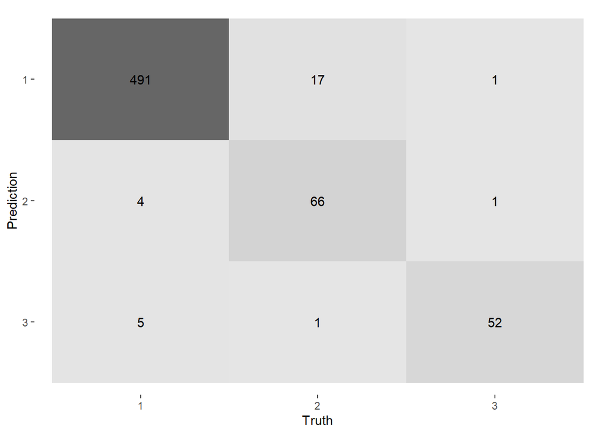

```r
##confusion matrix
augment(boost_final, new_data = fetal_test) %>%
  conf_mat(truth = fetal_health, estimate = .pred_class) %>%
  autoplot(type = "heatmap")
```

Let’s take a quick look at the ROC curve, which looks great, because we want the curve to follow the trajectory of up and left as much as possible. Auc value is 98.98%.

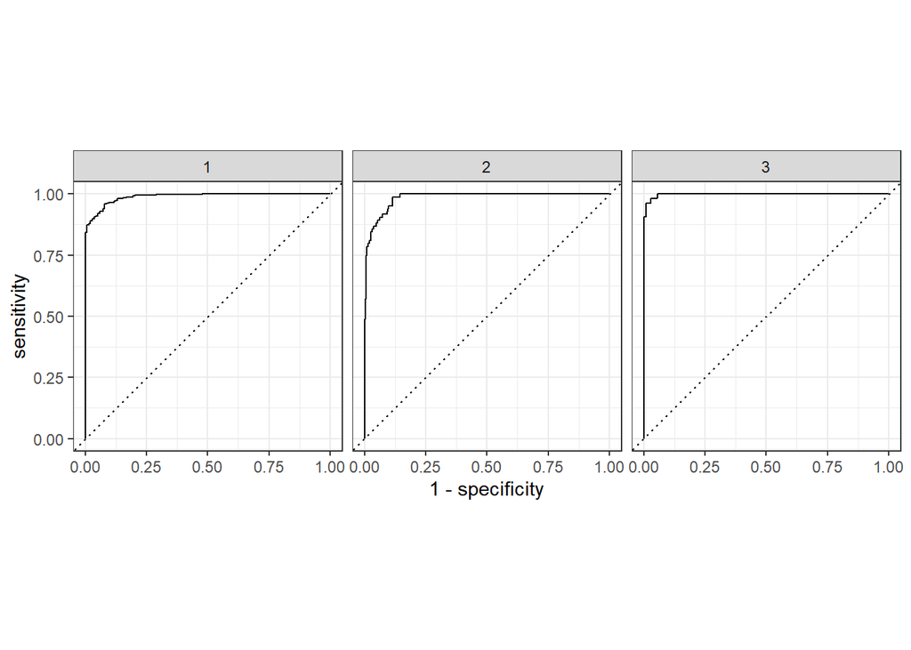

```r
#roc_curve
augment(boost_final, new_data = fetal_test) %>%
  roc_curve(fetal_health, .pred_1:.pred_3) %>%
  autoplot()
```

```r
final_roc_auc <- augment(boost_final, new_data = fetal_test) %>%
  roc_auc(fetal_health, estimate = .pred_1:.pred_3) %>%
  select(.estimate)  # computing the AUC for the ROC curve

final_roc_auc
```

```
## # A tibble: 1 x 1
##   .estimate
##       <dbl>
## 1     0.990
```

## Conclusion

In this paper, four machine learning models, namely, logistic regression, decision tree, boost and SVM, are selected to predict the health of the fetus through the relevant indicators of CTGs We use the five fold cross validation method to compare the auc values of the four models after tuning the parameters. The boost model has the best effect, with the average auc value reaching 97.95%. Then we use the optimized boost model as our final model and fit the training set and test set. The model performs well on the test set, with the accuracy rate of 95.45% and AUC value of 98.98%. The only disadvantage is that we may be able to further optimize the fetal prediction for suspicious pathology.